# Neurological condition analysis

```r
library(tidyverse)
library(readxl)
library(DT)
library(rcartocolor)
library(gghighlight)
library(cowplot)
library(broom)
library(icd)
library(tableone)

theme_set(theme_bw() +
            theme(legend.title = element_blank(),
                  panel.grid.minor = element_blank()))
for (r_file in list.files('R/', full.names = TRUE)) source(r_file)
```

```r
# clin_raw <- read_csv('../../Phase2.1/Date_Shifted_Files/LocalPatientClinicalCourse_Shift.csv')
# demo_raw <- read_csv(
#    '../../Phase2.1/Date_Shifted_Files/LocalPatientSummary_Shift.csv',
#                       na = '1900-01-01')
# obs_raw <- read_csv('../../Phase2.1/LocalPatientObservations.csv')
```

```r
clin_raw <-
  read_csv(
    '../thrombotic-penn/data/LocalPatientClinicalCourse.csv',
    col_types = list(patient_num = col_character())
  )
demo_raw <-
  read_csv(
    '../thrombotic-penn/data/LocalPatientSummary.csv',
    col_types = list(patient_num = col_character()),
    na = '1900-01-01'
  )
obs_raw <-
  read_csv(
    '../thrombotic-penn/data/LocalPatientObservations.csv',
    col_types = list(patient_num = col_character())
  )
```

```r
loinc <- read_csv('public-data/loinc-map.csv')
neuro_icds_10 <- read_excel('public-data/2020-09-10_neuro-icd10.xlsx') %>%
  rename('icd' = `ICD-10`)
```

## Data pre-processing

In this initial analysis, we will consider neuro patients as those with a neuro code on the day **of** or **anytime after** their first day of admission. These patients developed neurological conditions after COVID-19 related admission.

Only examining ICD-10 for now.

*Note: We will need to discuss whether we want to include codes assigned on the day of admission as comorbidities.*

```r
neuro_patients <- obs_raw %>%
  filter(
    days_since_admission >= 0,
    concept_code %in% neuro_icds_10$icd) %>%
  distinct(patient_num, concept_code)

neuro_pt_post <- unique(neuro_patients$patient_num)

non_neuro_patients <- data.frame(
  patient_num = setdiff(demo_raw$patient_num, neuro_pt_post)) %>%
  mutate(concept_code = 'NN')

readmissions <- clin_raw %>%
  group_by(patient_num) %>%
  mutate(delta_hospitalized = diff(c(in_hospital[1], in_hospital))) %>%
  ungroup() %>%
  filter(delta_hospitalized != 0,
         in_hospital == 1) %>%
  add_count(patient_num, name = 'n_readmissions') %>%
  # add_count(patient_num, name = 'status_changes') %>%
  # filter(status_changes > 1) %>%
  # mutate(n_readmissions = (status_changes - 1)/2) %>%
  arrange(desc(n_readmissions))

length(unique(readmissions$patient_num))
```

```
## [1] 1384
```

```r
re_admin_stats <- readmissions %>%
  select(patient_num, n_readmissions) %>%
  distinct() %>%
  count(n_readmissions)

re_admin_stats
```

```
## # A tibble: 30 x 2
##    n_readmissions     n
##             <int> <int>
##  1              1   582
##  2              2   235
##  3              3   170
##  4              4   103
##  5              5    83
##  6              6    55
##  7              7    33
##  8              8    21
##  9              9    21
## 10             10    14
## # … with 20 more rows
```

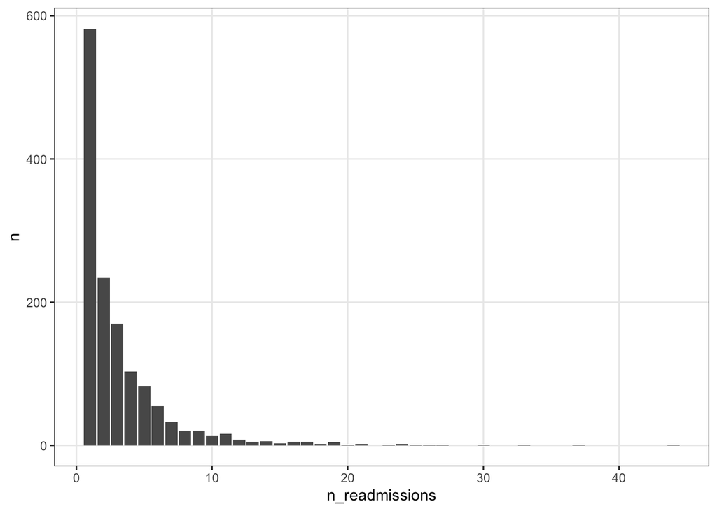

```r
re_admin_stats %>%
  ggplot() +
  geom_col(aes(x = n_readmissions, y = n))
```

```r
days_count_min_max <- obs_raw %>%
  group_by(patient_num) %>%
  summarise(
    distinct_days = n_distinct(days_since_admission),
    min_hos = min(days_since_admission),
    # n_stay = max(days_since_admission),
    .groups = 'drop'
  )

demo_df <- demo_raw %>%
  mutate(time_to_severe = severe_date - admission_date,
         time_to_severe = ifelse(time_to_severe < 0, NA, time_to_severe),
         time_to_death = death_date - admission_date,
         time_to_death = ifelse(time_to_death < 0, NA, time_to_death),
         readmitted = patient_num %in% readmissions$patient_num,
         neuro_post = patient_num %in% neuro_pt_post %>%
           as.factor() %>%
           fct_recode(`Has neurological condition` = "TRUE",
                      `No neurological condition` = "FALSE"),
         Survival = as.factor(deceased) %>%
           fct_recode(Alive = "0", Deceased = "1"),
         sex = as.factor(sex),
         race = as.factor(race),
         age_group = as.factor(age_group),
         Severity = as.factor(severe) %>%
           fct_recode(Severe = "1", `Non-severe` = "0"),
         n_stay = as.numeric(last_discharge_date - admission_date,
                             units="days")) %>%
  left_join(days_count_min_max, by = 'patient_num')
```

## Demographics (Table 1)

```r
formatted_demo <- demo_df %>%
  select(Sex = sex, `Age group` = age_group,
         Race = race, Severity, Survival,
         `Time to severity onset (days)` = time_to_severe,
         `Time to death (days)` = time_to_death,
         Readmitted = readmitted, neuro_post)

## export table 1 to csv
table_one_vars <- setdiff(colnames(formatted_demo), 'neuro_post')
demo_table <- tableone::CreateTableOne(
  data = formatted_demo,
  vars = table_one_vars,
  strata= "neuro_post")

table_one <- print(
  demo_table,
  showAllLevels = TRUE,
  formatOptions = list(big.mark = ","),
  printToggle = FALSE
)

## print table 1 html
table1::table1(
  ~ Sex + `Age group` + Race + Severity + Survival + Readmitted +
    `Time to severity onset (days)` + `Time to death (days)`
  | neuro_post,
  data = formatted_demo,
  overall = "Total",
  export = "results/demographics.csv")
```

|  | No neurological condition (N=1491) | Has neurological condition (N=1134) | Total (N=2625) |
| --- | --- | --- | --- |
| Sex |  |  |  |
| female | 803 (53.9%) | 586 (51.7%) | 1389 (52.9%) |
| male | 688 (46.1%) | 548 (48.3%) | 1236 (47.1%) |
| Age group |  |  |  |
| 00to02 | 1 (0.1%) | 0 (0%) | 1 (0.0%) |
| 12to17 | 1 (0.1%) | 1 (0.1%) | 2 (0.1%) |
| 18to25 | 124 (8.3%) | 27 (2.4%) | 151 (5.8%) |
| 26to49 | 485 (32.5%) | 171 (15.1%) | 656 (25.0%) |
| 50to69 | 523 (35.1%) | 399 (35.2%) | 922 (35.1%) |
| 70to79 | 193 (12.9%) | 244 (21.5%) | 437 (16.6%) |
| 80plus | 164 (11.0%) | 292 (25.7%) | 456 (17.4%) |
| Race |  |  |  |
| american_indian | 2 (0.1%) | 0 (0%) | 2 (0.1%) |
| asian | 72 (4.8%) | 30 (2.6%) | 102 (3.9%) |
| black | 734 (49.2%) | 589 (51.9%) | 1323 (50.4%) |
| hawaiian_pacific_islander | 1 (0.1%) | 0 (0%) | 1 (0.0%) |
| hispanic_latino | 54 (3.6%) | 18 (1.6%) | 72 (2.7%) |
| other | 64 (4.3%) | 48 (4.2%) | 112 (4.3%) |
| white | 564 (37.8%) | 449 (39.6%) | 1013 (38.6%) |
| Severity |  |  |  |
| Non-severe | 1046 (70.2%) | 605 (53.4%) | 1651 (62.9%) |
| Severe | 445 (29.8%) | 529 (46.6%) | 974 (37.1%) |
| Survival |  |  |  |
| Alive | 1364 (91.5%) | 867 (76.5%) | 2231 (85.0%) |
| Deceased | 127 (8.5%) | 267 (23.5%) | 394 (15.0%) |
| Readmitted |  |  |  |
| Yes | 641 (43.0%) | 743 (65.5%) | 1384 (52.7%) |
| No | 850 (57.0%) | 391 (34.5%) | 1241 (47.3%) |
| Time to severity onset (days) |  |  |  |
| Mean (SD) | 20.0 (41.6) | 12.7 (34.1) | 16.0 (37.8) |
| Median [Min, Max] | 1.00 [0, 228] | 0 [0, 223] | 1.00 [0, 228] |
| Missing | 1046 (70.2%) | 605 (53.4%) | 1651 (62.9%) |
| Time to death (days) |  |  |  |
| Mean (SD) | 119 (151) | 126 (147) | 124 (148) |
| Median [Min, Max] | 25.0 [1.00, 535] | 49.0 [0, 531] | 42.5 [0, 535] |
| Missing | 1364 (91.5%) | 867 (76.5%) | 2231 (85.0%) |

## Comorbidity

```r
n_patients <- nrow(demo_raw)
obs_raw <- obs_raw %>%
  filter(concept_type %in% c("DIAG-ICD10", "DIAG-ICD9"))
```

New variable `neuro_post` to indicate whether the patient developed neurological conditions after COVID-19 related admission.

Q: What about on the day of? (==0)

```r
table(demo_df$neuro_post)
```

```
##
##  No neurological condition Has neurological condition
##                       1491                       1134
```

## Map comorbidities

List of comorbidity abbreviations for reference purposes, then run the `map_charlson_codes()` function:

```r
# for charlson or quan-deyo
comorb_names <- get_charlson_names()
comorbs <- as.vector(comorb_names$Abbreviation)

# for elixhauser
#comorb_names <- get_quan_elix_names()
#comorbs <- as.vector(comorb_names$Abbreviation)

# t1: earliest time point to consider comorbidities
# t2: latest time point to consider comorbidities
# example <- t1 = -365, and t2 = -1 will map all all codes up to a year prior but before admission (admission = day 0)
comorb <- map_charlson_codes(df = obs_raw,
                             comorb_names = comorb_names,
                             t1 = -365,
                             t2 = -1,
                             map_type = 'charlson')
```

`map_charlson_codes()` outputs a 2-element lists:

1- Dataframe of the Charlson comorbidity index scores

2- Dataframe of the specific mapped codes arranged by frequency. Comorbidity mapping of all patients with ICD codes prior to admission, regardless of whether or not they had a comorbidity.

```r
index_scores <- comorb$index_scores
mapped_codes_table <- comorb$mapped_codes_table
comorb_names$Abbreviation <- as.character(comorb_names$Abbreviation)
```

Here we can determine how many unique patients we have comorbidity index for prior to admission:

```r
length(unique(index_scores$patient_num))
```

```
## [1] 1816
```

## Comorbidity matrix

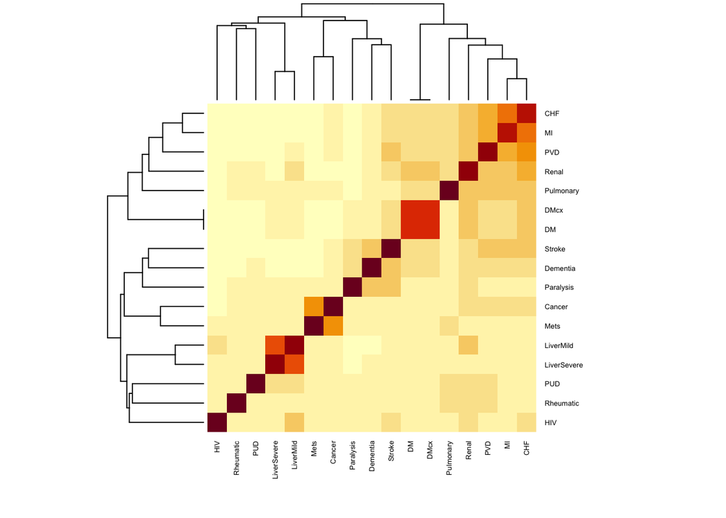

```r
n_comorbs <- colSums(index_scores[, comorbs])
pos_comorbs <- names(n_comorbs[n_comorbs > 0])

index_scores[, pos_comorbs] %>%
  cor() %>%
  heatmap(cexRow = 0.5, cexCol = 0.5)
```

## Charlson scores

### Distribution

The below code will join the comorbidity mappings and the neurological code information, basic demographic and hospital mortality information into one dataframe.

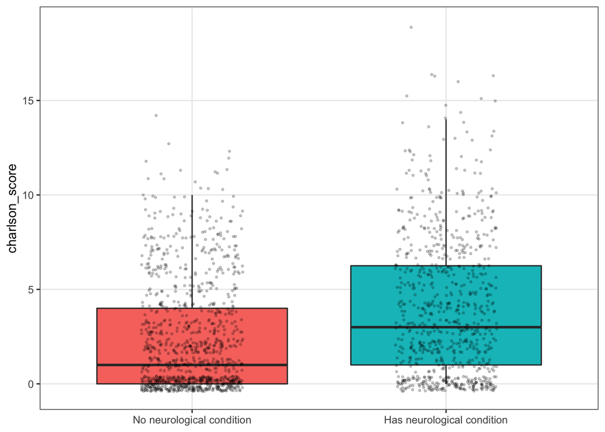

```r
demo_df$patient_num <- as.character(demo_df$patient_num)
obs_raw$patient_num <- as.character(obs_raw$patient_num)

scores_unique <- index_scores %>%
  left_join(demo_df, by = 'patient_num') %>%
  mutate(severe = as.factor(severe) %>%
           fct_recode('Severe' = '1', 'Non-severe' = '0'))

scores_neuro <- obs_raw %>%
  # 1 patient can have different code but each only counted once
  distinct(patient_num, concept_code) %>%
  left_join(neuro_icds_10, by = c('concept_code' = 'icd')) %>%
  left_join(scores_unique, by = 'patient_num') %>%
  filter(!is.na(charlson_score)) %>%
  mutate(concept_code = case_when(
           is.na(`Neurological Disease Category`) ~ 'NN',
           TRUE ~ concept_code) %>%
           as.factor() %>%
           fct_reorder(- charlson_score),
         `Neurological Disease Category` =
           as.factor(`Neurological Disease Category`) %>%
           fct_reorder(charlson_score)) %>%
  {.}

scores_unique %>%
  ggplot(aes(x = neuro_post, y = charlson_score, fill = neuro_post)) +
  geom_boxplot(outlier.colour = NA) +
  geom_jitter(alpha = 0.2, width = 0.2, size = 0.6) +
  guides(fill = FALSE) +
  labs(x = NULL) +
  NULL
```

### Comorbidity table

```r
combined_table1 <- get_table1(
  index_scores %>% filter(patient_num %in% neuro_pt_post)) %>%
  rename('n_neuro_pats' = n_patients) %>%
  left_join(get_table1(index_scores), .,
            by = c("Comorbidity", "Abbreviation")) %>%
  mutate(prop_patients = n_patients/nrow(demo_raw),
         prop_neuro_pats = n_neuro_pats/nrow(demo_raw))

write.csv(combined_table1, "results/table1_combined.csv", row.names = FALSE)

datatable(combined_table1) %>%
  formatPercentage(c('prop_patients', 'prop_neuro_pats'))
```

|  | Comorbidity | Abbreviation | n_patients | n_neuro_pats | prop_patients | prop_neuro_pats |
| --- | --- | --- | --- | --- | --- | --- |
| 1 | Myocardial Infarction | MI | 303 | 180 | 0.115428571428571 | 0.0685714285714286 |
| 2 | Congestive Heart Failure | CHF | 464 | 263 | 0.176761904761905 | 0.100190476190476 |
| 3 | Periphral Vascular Disease | PVD | 362 | 203 | 0.137904761904762 | 0.0773333333333333 |
| 4 | Cerebrovascular Disease | Stroke | 230 | 169 | 0.0876190476190476 | 0.0643809523809524 |
| 5 | Dementia | Dementia | 179 | 146 | 0.0681904761904762 | 0.0556190476190476 |
| 6 | Chronic Pulmonary Disease | Pulmonary | 441 | 232 | 0.168 | 0.0883809523809524 |
| 7 | Connective Tissue Disease-Rheumatic Disease | Rheumatic | 67 | 35 | 0.0255238095238095 | 0.0133333333333333 |
| 8 | Peptic Ulcer Disease | PUD | 31 | 16 | 0.0118095238095238 | 0.0060952380952381 |
| 9 | Mild Liver Disease | LiverMild | 203 | 112 | 0.0773333333333333 | 0.0426666666666667 |
| 10 | Diabetes without complications | DM | 603 | 312 | 0.229714285714286 | 0.118857142857143 |

[output cut: 7 more lines]

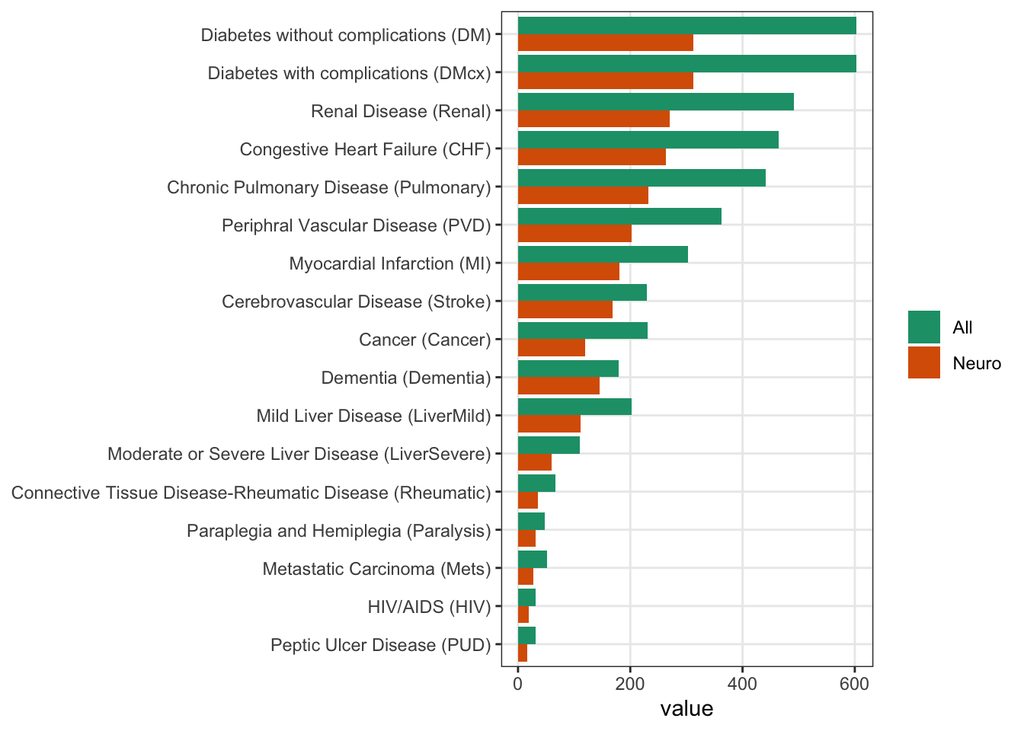

```r
combined_table1 %>%
  pivot_longer(c(n_patients, n_neuro_pats)) %>%
  mutate(fullname = glue::glue('{Comorbidity} ({Abbreviation})'))%>%
  ggplot(aes(x = value, y = fct_reorder(fullname, value), fill = name)) +
  geom_col(position = 'dodge') +
  scale_fill_brewer(palette = 'Dark2', direction = -1,
                    guide = guide_legend(reverse=TRUE),
                    label = c('Neuro', 'All')) +
  labs(y = NULL)
```

## Charlson score for each comorbidity type (neuro vs non-neuro)

```r
# Neuro vs non-neuro patients
comorb_long <- scores_unique %>%
  select(patient_num, neuro_post, charlson_score, any_of(pos_comorbs)) %>%
  pivot_longer(any_of(comorbs)) %>%
  filter(value == 1)

comorb_wilcox_func <- function(comorb, df = comorb_long) {
  df <- df %>% filter(name == comorb)
  neuro <- df %>% filter(neuro_post == 'Neuro')
  non_neuro <- df %>% filter(neuro_post == 'Non-neuro')
  try(wilcox.test(neuro$charlson_score, non_neuro$charlson_score)$p.value, silent = TRUE)
}

wilcox_res <- pos_comorbs %>%
  sapply(comorb_wilcox_func, df = comorb_long) %>%
  data.frame(p_value = .) %>%
  cbind(pos_comorbs) %>%
  filter(!(grepl('Error', p_value))) %>%
  arrange(p_value)

wilcox_res
```

```
## [1] p_value     pos_comorbs
## <0 rows> (or 0-length row.names)
```

## Short term outcomes

Do hospitalized COVID-19 patients with neurological conditions have a different short-term natural history (hospital days, death, severity, readmission) from those without?

Resolution: Charlson score vs comorbidity type, Neurological condition (TRUE/FALSE) vs. neurological ICD code?

```r
severe_reg <- glm(severe ~ neuro_post + charlson_score + sex + age_group + race,
   data = scores_unique, family = 'binomial') %>%
  tidy()
severe_reg
```

```
## # A tibble: 15 x 5
##    term                               estimate std.error  statistic      p.value
##    <chr>                                 <dbl>     <dbl>      <dbl>        <dbl>
##  1 (Intercept)                        -26.2     653.     -0.0401         9.68e-1
##  2 neuro_postHas neurological condit…   0.564     0.106   5.32           1.03e-7
##  3 charlson_score                       0.0958    0.0161  5.94           2.92e-9
##  4 sexmale                              0.0715    0.103   0.695          4.87e-1
##  5 age_group18to25                     12.1     535.      0.0226         9.82e-1
##  6 age_group26to49                     12.3     535.      0.0230         9.82e-1
##  7 age_group50to69                     12.5     535.      0.0233         9.81e-1
##  8 age_group70to79                     12.5     535.      0.0234         9.81e-1
##  9 age_group80plus                     12.0     535.      0.0224         9.82e-1
## 10 raceasian                           12.6     373.      0.0338         9.73e-1
## 11 raceblack                           12.8     373.      0.0342         9.73e-1
## 12 racehawaiian_pacific_islander       -0.0472  653.     -0.0000723      1.00e+0
## 13 racehispanic_latino                 12.4     373.      0.0333         9.73e-1
## 14 raceother                           12.7     373.      0.0341         9.73e-1
## 15 racewhite                           12.6     373.      0.0337         9.73e-1
```

```r
deceased_reg <- glm(deceased ~ neuro_post + charlson_score + sex + age_group + race,
   data = scores_unique, family = 'binomial') %>%
  tidy()
deceased_reg
```

```
## # A tibble: 15 x 5
##    term                                 estimate std.error statistic     p.value
##    <chr>                                   <dbl>     <dbl>     <dbl>       <dbl>
##  1 (Intercept)                          -26.4    1069.     -0.0247   0.980
##  2 neuro_postHas neurological condition   0.711     0.155   4.58     0.00000464
##  3 charlson_score                         0.104     0.0207  5.02     0.000000515
##  4 sexmale                                0.0795    0.147   0.539    0.590
##  5 age_group18to25                       10.6     883.      0.0121   0.990
##  6 age_group26to49                       10.9     883.      0.0123   0.990
##  7 age_group50to69                       11.9     883.      0.0135   0.989
##  8 age_group70to79                       12.3     883.      0.0139   0.989
##  9 age_group80plus                       13.2     883.      0.0149   0.988
## 10 raceasian                             11.6     604.      0.0191   0.985
## 11 raceblack                             11.4     604.      0.0189   0.985
## 12 racehawaiian_pacific_islander         -0.322  1069.     -0.000301 1.00
## 13 racehispanic_latino                   11.3     604.      0.0187   0.985
## 14 raceother                             11.5     604.      0.0191   0.985
## 15 racewhite                             11.8     604.      0.0195   0.984
```

### Length of stay

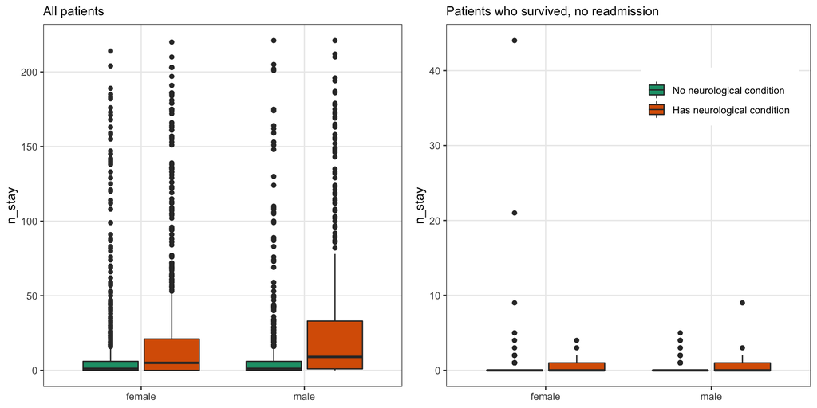

```r
left_stay <- demo_df %>%
  ggplot(aes(x = sex, y = n_stay, fill = neuro_post)) +
  geom_boxplot() +
  scale_fill_brewer(palette = 'Dark2', guide = FALSE) +
  labs(x = NULL , subtitle = 'All patients') +
  NULL

right_stay <- demo_df %>%
  filter(!readmitted, !deceased) %>%
  ggplot(aes(x = sex, y = n_stay, fill = neuro_post)) +
  geom_boxplot() +
  scale_fill_brewer(palette = 'Dark2') +
  labs(x = NULL , subtitle =  'Patients who survived, no readmission') +
  theme(legend.position = c(0.75, 0.8)) +
  NULL
plot_grid(left_stay, right_stay)
```

```r
n_stay_reg <- lm(n_stay ~ neuro_post + charlson_score + race + sex + age_group,
   data = scores_unique) %>%
  tidy()

n_stay_reg
```

```
## # A tibble: 15 x 5
##    term                                 estimate std.error statistic  p.value
##    <chr>                                   <dbl>     <dbl>     <dbl>    <dbl>
##  1 (Intercept)                           -16.3      50.1     -0.326  7.44e- 1
##  2 neuro_postHas neurological condition   15.2       2.06     7.39   2.21e-13
##  3 charlson_score                          2.81      0.312    9.00   5.56e-19
##  4 raceasian                              11.9      29.4      0.405  6.86e- 1
##  5 raceblack                              12.2      28.9      0.423  6.73e- 1
##  6 racehawaiian_pacific_islander           5.13     50.1      0.102  9.18e- 1
##  7 racehispanic_latino                     1.81     29.6      0.0610 9.51e- 1
##  8 raceother                               8.43     29.4      0.287  7.74e- 1
##  9 racewhite                              16.3      29.0      0.564  5.73e- 1
## 10 sexmale                                 0.355     1.97     0.180  8.57e- 1
## 11 age_group18to25                        16.4      41.1      0.399  6.90e- 1
## 12 age_group26to49                        13.4      40.9      0.327  7.44e- 1
## 13 age_group50to69                         8.03     40.9      0.196  8.44e- 1
## 14 age_group70to79                        10.6      41.0      0.260  7.95e- 1
## 15 age_group80plus                        -1.35     40.9     -0.0330 9.74e- 1
```

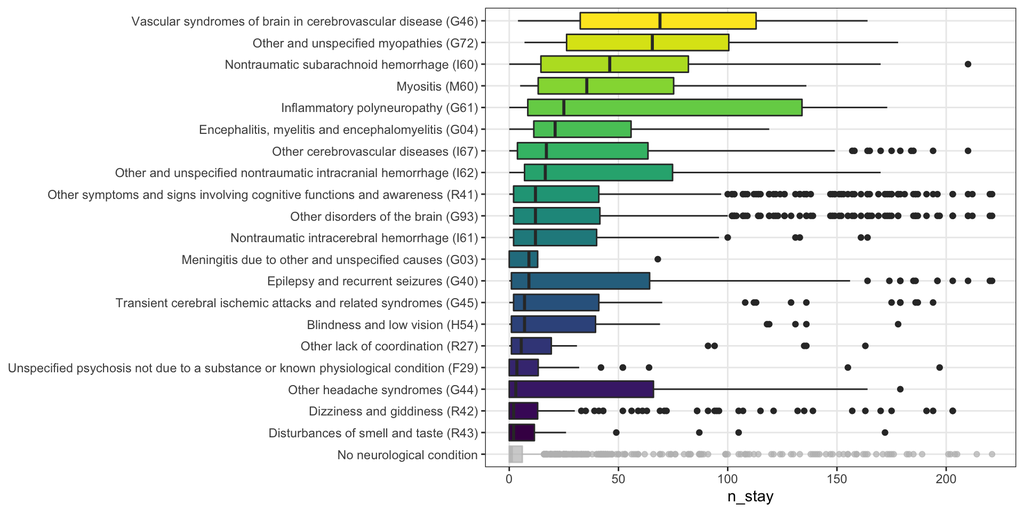

```r
nstay_df <- neuro_patients %>%
  bind_rows(non_neuro_patients) %>%
  left_join(demo_df, by = 'patient_num') %>%
  # mutate(concept_code = fct_reorder(concept_code, n_stay)) %>%
  left_join(neuro_icds_10, by = c('concept_code' = 'icd')) %>%
  mutate(full_icd = case_when(
    concept_code == 'NN' ~ 'No neurological condition',
    TRUE ~ paste0(`ICD-10 Description`, ' (', concept_code, ')')) %>%
             as.factor() %>% fct_reorder(n_stay))

nstay_df %>%
  ggplot(aes(y = full_icd, x = n_stay, fill = full_icd)) +
  labs(y = NULL) +
  geom_boxplot() +
  scale_fill_viridis_d(guide = FALSE) +
  gghighlight(concept_code != 'NN') +
  NULL
```

```r
summarised_stay <- nstay_df %>%
  group_by(concept_code) %>%
  summarise(mean_stay = mean(n_stay),
            sd_stay = sd(n_stay),
            n_patients = n(),
            .groups = 'drop')
```

### By neuro diagnosis

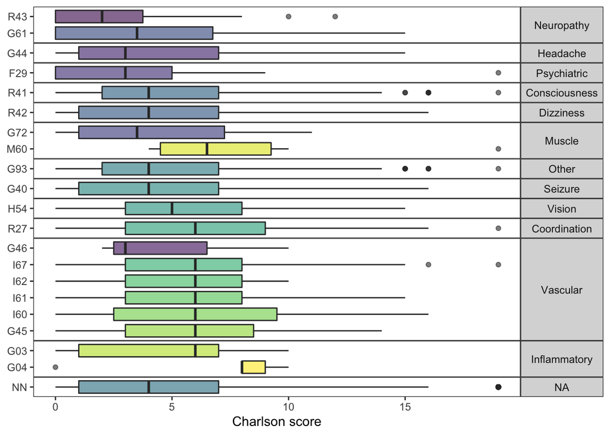

```r
# scores$patient_num <- as.numeric(as.character(scores$patient_num))
scores_neuro %>%
  filter(!is.na(charlson_score)) %>%
  ggplot(aes(y = concept_code, x = charlson_score, fill = concept_code)) +
  facet_grid(rows = vars(`Neurological Disease Category`),
             scales = 'free', space = 'free') +
  geom_boxplot(alpha = 0.6) +
  scale_fill_viridis_d(guide = FALSE, direction = -1) +
  labs(x = 'Charlson score', y = NULL) +
  NULL +
  theme(panel.grid = element_blank(),
        legend.title = element_text(),
        strip.text.y = element_text(angle = 0),
        panel.spacing.x = unit(10, "points"),
        panel.spacing.y = unit(0, "points"))
```

## Evaluating Timeframe of Comorbidities

Qs: When are these comorbidities getting mapped. Understanding ICD code assignnment can help us prevent confusing complications with comorbidities and vice versa.

It would be helpful to review the literature as well, what did the original developers of the comorbidity indexes do? How were they validated?

```r
# maps codes that occurred anytime 356 days prior to COVID admission
multi_comorb <- function(x) {
  process_tables(map_charlson_codes(obs_raw, comorb_names, x$t1, x$t2, map_type = 'charlson')[['index_scores']]) %>%
    mutate(time_map = x$label)
}

time_df <- tribble(
  ~ t1, ~ t2, ~ label,
  -365, -1, "1 to 365 days prior admission",
  -365, -15, "15 to 365 days prior admission",
  -14, -1, "14 to 1 days prior admission",
  0, 0, "Only Day of Admission",
  1, 1000, "Any Day After Admission"
)

all_tables <- lapply(time_df %>% split(1:5), multi_comorb) %>%
  do.call(rbind, .) %>%
  mutate(time_map = fct_relevel(time_map, time_df$label))
```

### Timeline - All Patients

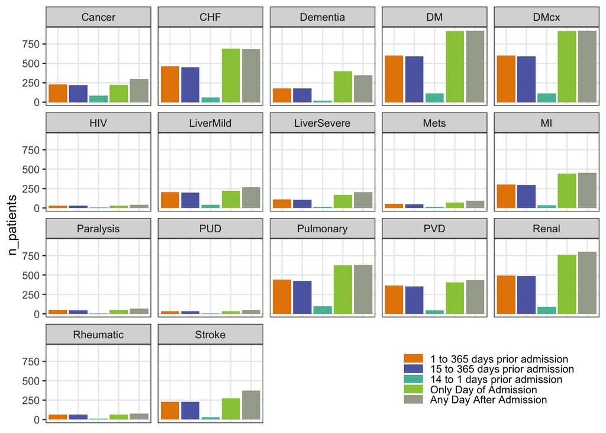

```r
ggplot(all_tables, aes(x = time_map,  y = n_patients, fill = time_map)) +
  geom_bar(stat = "identity") +
  facet_wrap( ~ Abbreviation) +
  scale_fill_carto_d() +
  theme(
    legend.position = c(0.8, 0.12),
    legend.key.height = unit(3, 'mm'),
    axis.title.x = element_blank(),
    axis.text.x = element_blank(),
    axis.ticks.x = element_blank()
  )
```

## First occurence of a comorbidity

The below figure plots the first time a patient had an ICD code map to that specific comorbidity.

Perhaps could go a conservative route and only include comorbidities if there was a previous record of it? However, each comorbidity category can contain multiple different types of diseases. So perhaps could be problematic.

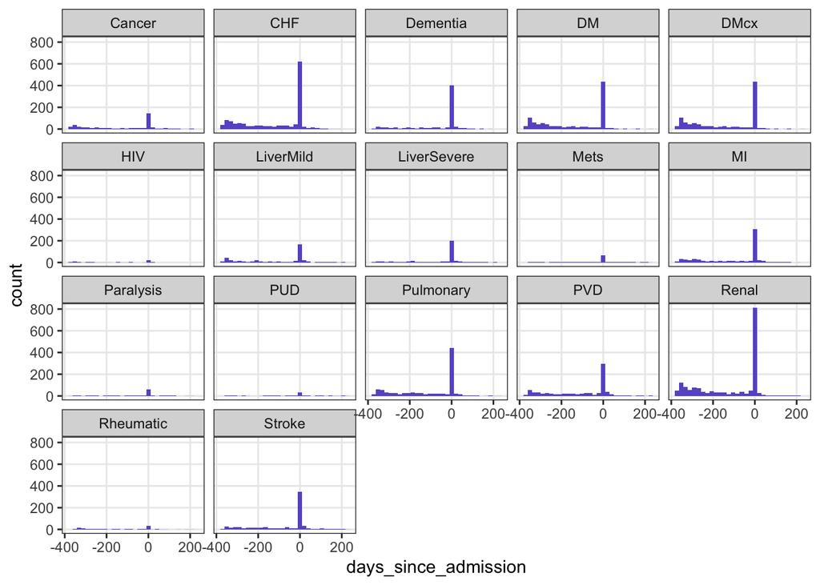

```r
obs_first <- obs_raw %>%
  group_by(patient_num) %>%
  merge(mapped_codes_table, by = "concept_code") %>%
  arrange(days_since_admission) %>%
  group_by(patient_num, Abbreviation) %>%
  mutate(first_occurence = min(days_since_admission),
         first_occurence_indicator = if_else(first_occurence == days_since_admission, 1, 0)) %>%
  ungroup()  %>%
  filter(first_occurence_indicator == 1)

ggplot(obs_first, aes(x = days_since_admission)) +
  geom_histogram(fill = 'slateblue') +
   facet_wrap(~Abbreviation)
```

## Neuro Patients timeline of first neuro diagnosis

If this is helpful, we may want to move to the explore-neuro.rmd file.

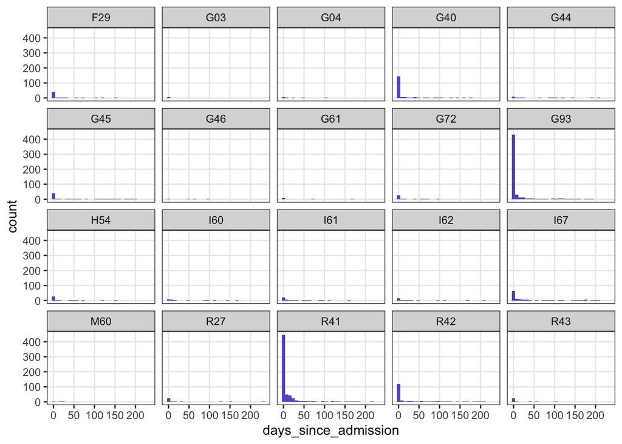

```r
post_adm_neuro_pats <- obs_raw %>%
  filter(days_since_admission >= 0) %>%
  right_join(neuro_icds_10, by = c('concept_code' = 'icd')) %>%
  group_by(patient_num, concept_code) %>%
  mutate(first_occurence = min(days_since_admission),
         first_occurence_indicator = if_else(first_occurence == days_since_admission, 1, 0)) %>%
  ungroup()  %>%
  filter(first_occurence_indicator == 1)

ggplot(post_adm_neuro_pats, aes(x = days_since_admission)) +
  geom_histogram(fill = 'slateblue') +
   facet_wrap(~concept_code)
```

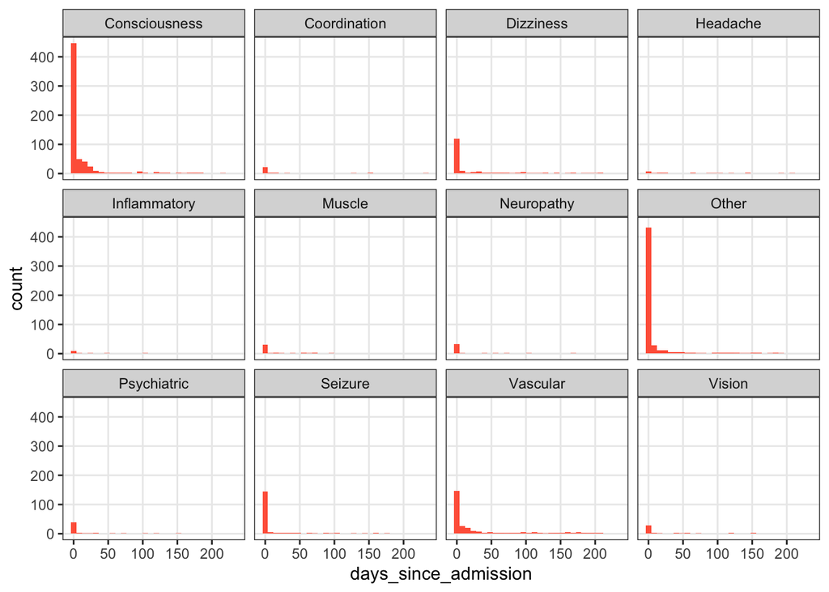

```r
ggplot(post_adm_neuro_pats, aes(x = days_since_admission)) +
  geom_histogram(fill = 'tomato') +
   facet_wrap(~`Neurological Disease Category`)
```

## Additional Notes:

Neuro Codes: G04, G45, G46, I60, 161, 162, and 167 will map to comorbidities. An important consideration is that we don’t want to confuse comorbidities for complications of hospital stay/COVID-19

The below will assess how many on these neuro comorbidity codes occurred on the day of admission and how many neuro codes in general are on the day of admission.

*Note: This is just for data exploration right now, we are going to initially just assume that any codes prior to the COVID-19 admission are comorbidities*

```r
neuro_comorb_codes <- c("G04", "G45", "G46",  # paralysis codes
                        "I60", "161", "162", "167") # stroke codes

neuro_comorb_on_admission <- obs_raw %>%
  filter(days_since_admission == 0) %>%
  filter(concept_code %in% neuro_comorb_codes) %>%
  select(patient_num, concept_code) %>%
  distinct()
unique(neuro_comorb_on_admission$concept_code)
```

```
## [1] "I60" "G04" "G45" "G46"
```

```r
summarised_stay_penn = summarised_stay
n_stay_reg_penn = n_stay_reg
severe_reg_penn = severe_reg
deceased_reg_penn = deceased_reg
table_one_penn = table_one
write.csv(table_one_penn, file = "results/penn-table1.csv")

save(summarised_stay_penn,
     severe_reg_penn,
     deceased_reg_penn,
     table_one_penn,
     n_stay_reg_penn,
     file = 'results/penn-results.rda')
```